# Understanding Market Shocks Through Time Series Analysis

Using COVID-19 and the Stock Market to Learn Time Series

Devansh Sachar

2026-05-27

## What Is a Time Series?

A **time series** is a sequence of values recorded at regular points in time — daily, monthly, hourly, or any consistent interval.

What makes it different from a normal data table: **the order of rows matters.** Monday is connected to Tuesday. You cannot shuffle the data without losing information.

**Every time series has two parts:**

📅

**Timestamp**  
When was it recorded?

📏

**Value**  
What was measured?

💡 **Our example:** Stock market daily returns, 2018–2022. COVID-19 creates a visible “before, during, and after” — perfect for seeing every time series concept clearly.

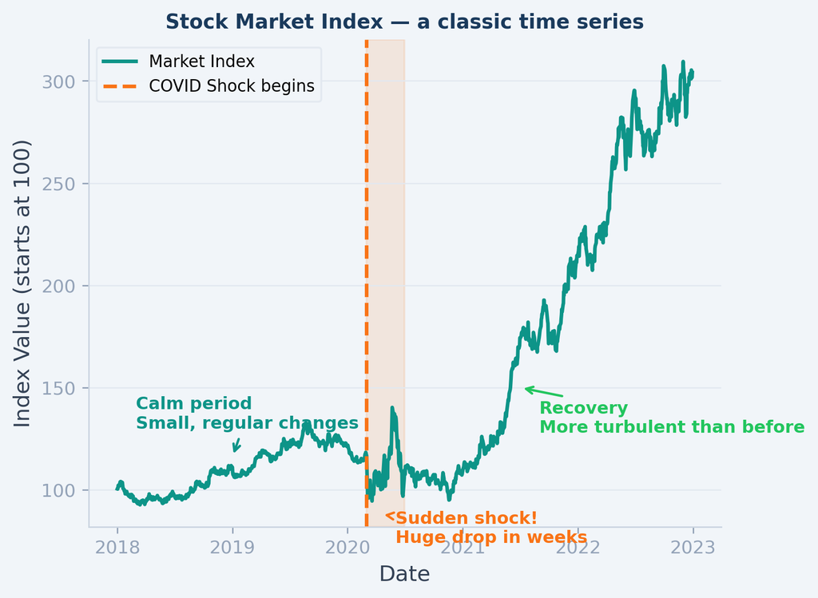

## Concept 1 — Trend & Stationarity

### 📈 Trend — the Long-Run Direction

The **trend** is the overall direction of the series after smoothing out noise. We find it using a **rolling mean** — averaging the last N observations as we slide along.

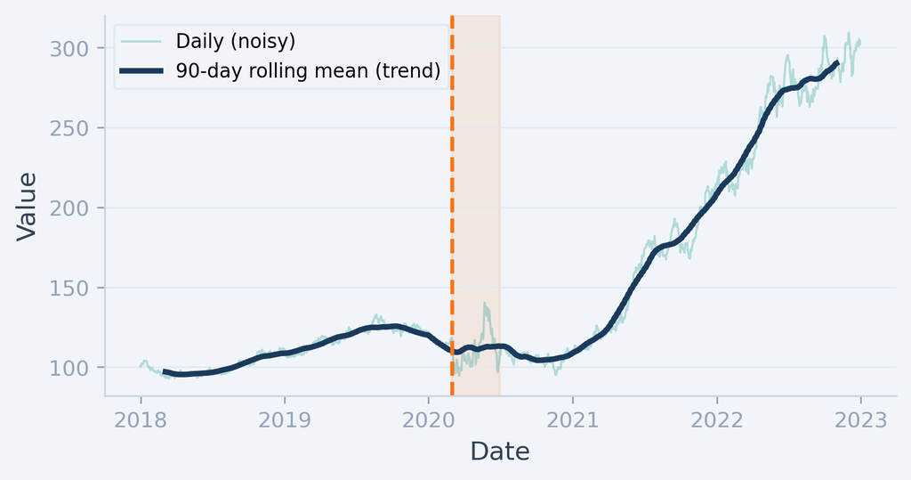

The navy line removes the noise — now the **up → crash → recover** direction is obvious.

### 🔄 Stationarity — Does It Stay Consistent?

A series is **stationary** when its mean and spread stay roughly stable over time. Almost every time series model requires this.

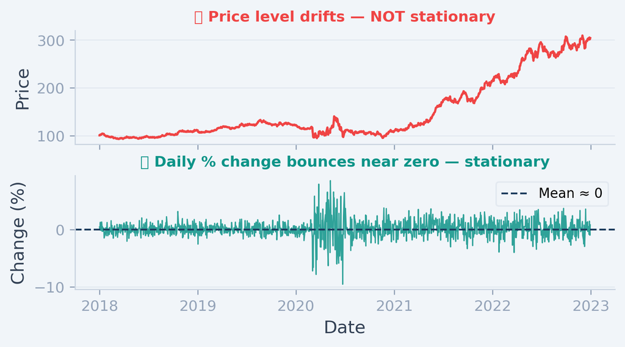

**The fix:** Use the **daily % change** instead of the raw level. Changes stay near zero — stationary. The rising price series is not.

## Concept 2 — Rolling Windows & Volatility

### 🪟 What Is a Rolling Window?

A rolling window slides along the series and recomputes a statistic using only the **most recent N observations.** This turns a single summary number into a **story over time.**

1

#### Pick a window size

e.g. 30 days — how far back do you look?

2

#### Compute the statistic

Mean, std dev, sum — whatever you need

3

#### Slide forward one day, repeat

You now have a value for every date

### 📊 Volatility = Rolling Std Dev

**Volatility** measures how much the series jumps around day to day. We compute it as the **rolling standard deviation** of daily changes over the last 30 days.

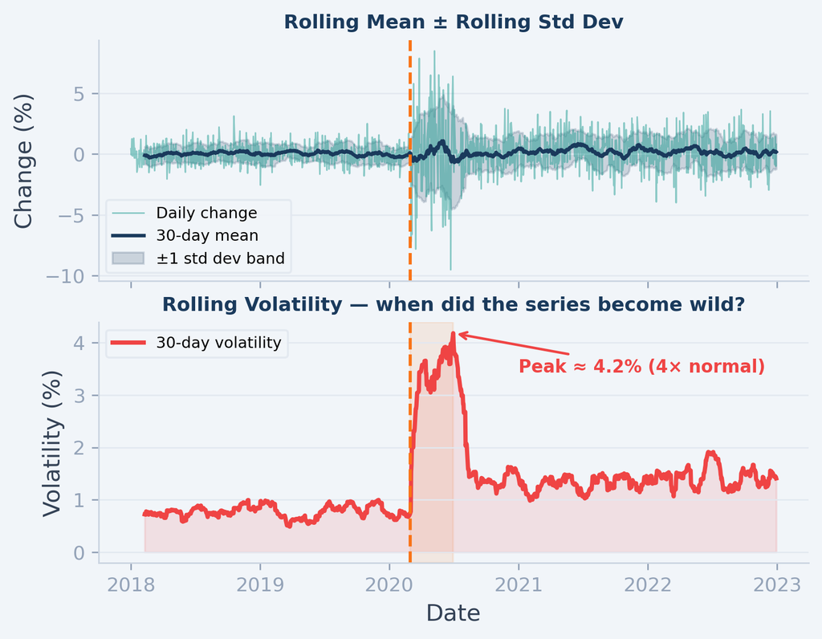

⚡ The rolling window turns one number into a timeline — you can see **exactly when** the series became risky, not just that it was risky overall.

## Concept 3 — Structural Break & Autocorrelation

### 💥 Structural Break — When the Pattern Changes Permanently

A structural break is a point where the series **permanently shifts** its behaviour. Models trained before the break will give wrong answers after it.

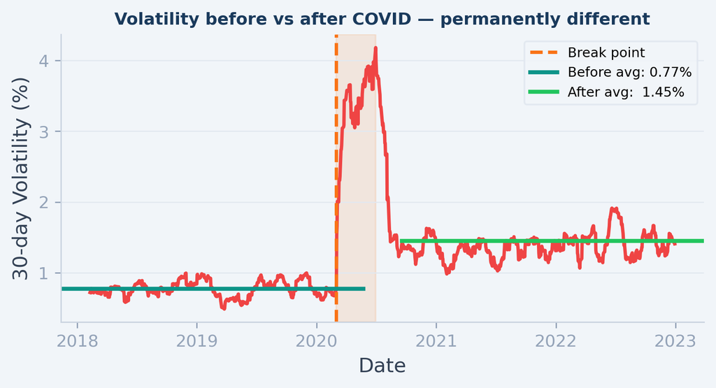

Volatility nearly **doubled and stayed there.** Any model built on pre-COVID data now underestimates risk.

### 🔁 Autocorrelation — Does the Past Predict the Future?

**Autocorrelation** measures whether today’s value is related to yesterday’s. If yes, the series has **memory** — useful for forecasting.

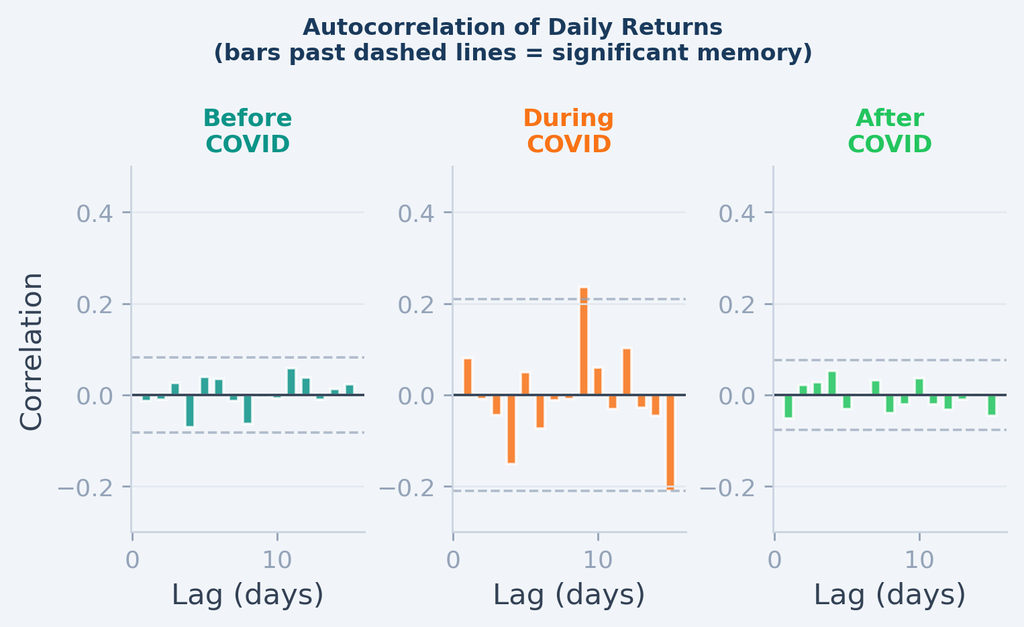

## Concept 4 — Anomaly Detection

An **anomaly** is a data point so far from normal that it signals something genuinely unusual happened. We use the **3-sigma rule** — the simplest detector that needs no labels, just the data’s own mean and spread.

### The 3-Sigma Rule

Flag a point if its distance from the mean is more than 3 standard deviations.

Flag if: |value − mean| > 3 × std dev

In normally distributed data, only **0.3%** of points fall that far out — so anything flagged is genuinely rare.

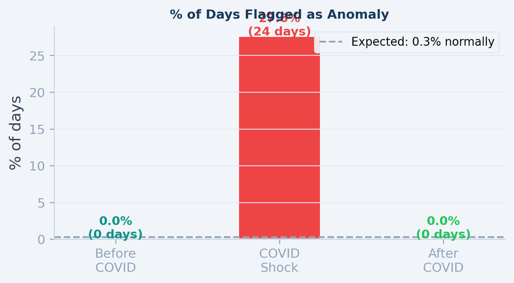

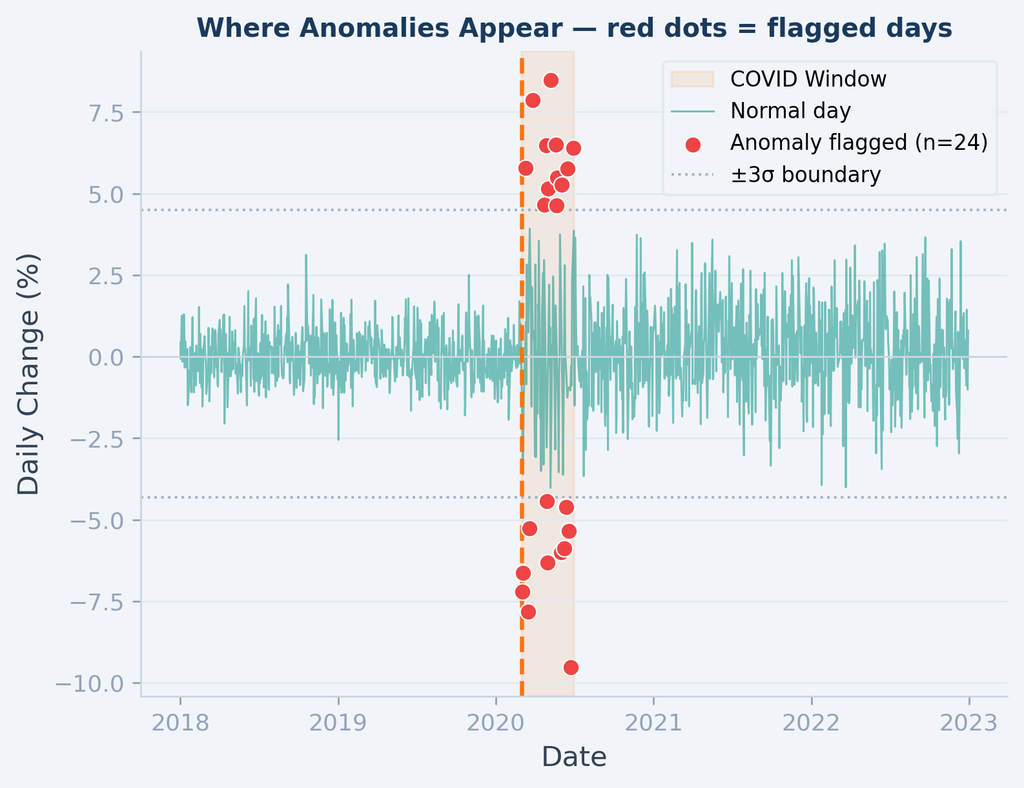

## Key Takeaways

01 Time Series = Ordered Data

A time series is values recorded over time where **order matters.** Monday connects to Tuesday. Shuffle the rows and you destroy the information.

02 Use Changes, Not Levels

Raw values that drift upward forever are **not stationary.** Use % changes instead — they bounce around zero and work with most analysis tools.

03 Rolling Windows Show When

A rolling mean or rolling std dev turns one summary number into a **timeline.** You see exactly when the series changed — not just that it changed overall.

04 Structural Breaks Need New Models

When behaviour **permanently changes,** old models stop working. Detecting the break point is step one — then you retrain on the new regime.

05 Autocorrelation = Memory

06 Simple Rules Detect Anomalies

💡

These tools work on **any data over time** — temperature, hospital admissions, website traffic, energy usage. COVID and the stock market are just our learning example.